# -

### Belügyi Munkacsoport: Kertai József Károly

**Bemutatkozás**

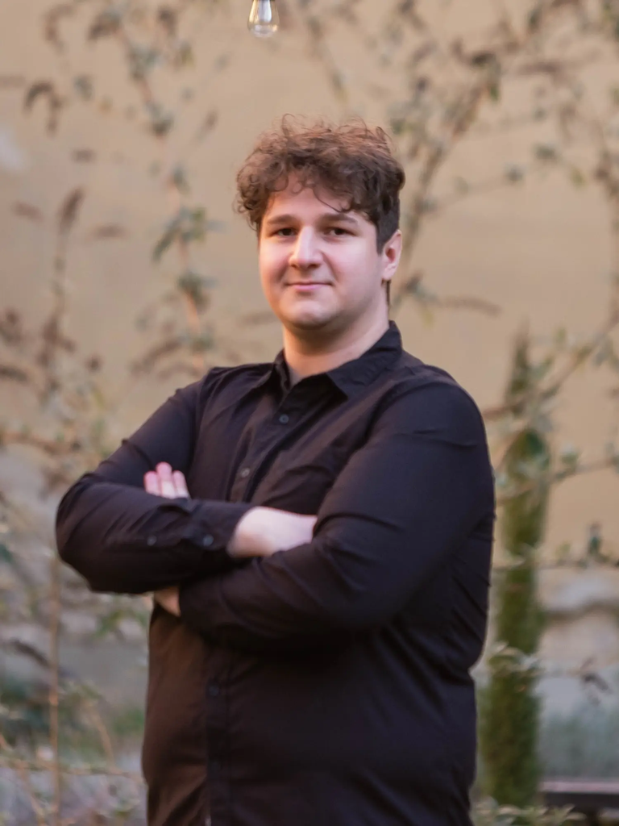

A Pécsi Tudományegyetem Általános Orvostudományi Karának hallgatójaként a tanulmányaim megkezdése óta vagyok kollégista. A Belügyi Munkacsoporttal azon dolgozunk, hogy a kollégium épületét napról-napra egyre komfortosabb és otthonosabb hellyé tegyük. Ennek elősegítésére többek közt szervezünk közös kertészkedéseket, részt veszünk a közösségi tereink tisztán tartásában, valamint együtt felelünk az eszközpark fejlesztéséért. A munkacsoport vezetőjeként szívügyem, hogy mindezt a fenntarthatóság jegyében vigyük véghez.

### Kommunikációs Munkacsoport: Magyar Tünde

**Bemutatkozás**

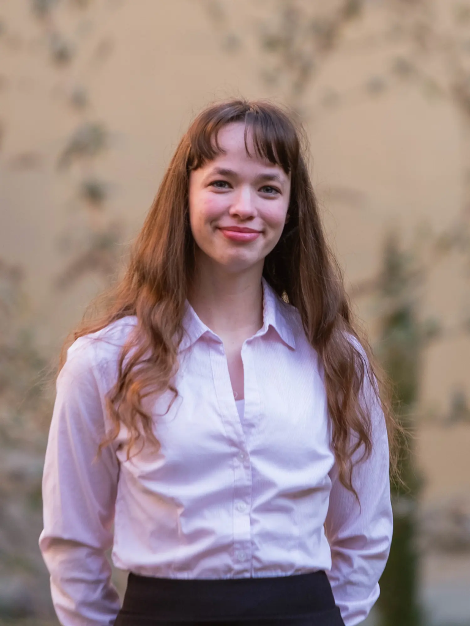

A Pécsi Tudományegyetem Egészségtudományi Karának Ápolás- és betegellátás, szülésznő szakos hallgatója vagyok. Munkacsoportommal képviseljük kollégiumunkat a közösségi médiában, illetve nálunk történik a honlap szerkesztése is. Fontos számomra, hogy megosszuk értékeinket, nyomon követhetőséget biztosítsunk programok szempontjából, emellett a jövőbeni jelentkezőknek is tájékozódási lehetőséget nyújtsunk.

### Közösségi Munkacsoport: Geréb Sarolta

**Bemutatkozás**

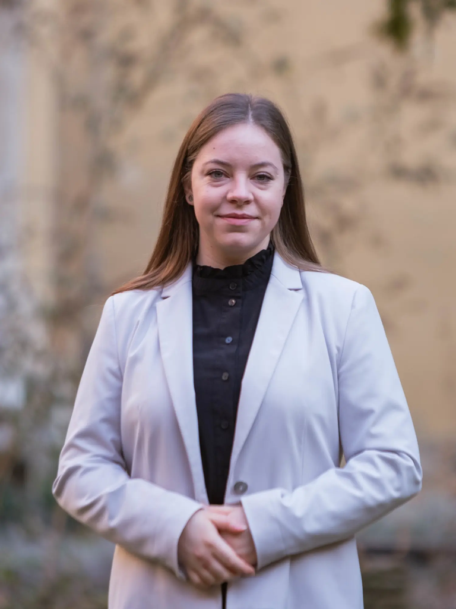

A Pécsi Tudományegyetem Egészségtudományi Karának Táplálkozástudományi mesterszakos hallgatójaként kollégiumunkban a Közösségi Munkacsoportért felelek. Fontosnak tartom, hogy az itt lakók ne csak szállásként tekintsenek a kollégiumra, hanem otthon is érezzék itt magukat, ezért célom, hogy a munkacsoportommal együtt olyan programokat szervezzünk, amelyek mindenki számára értéket és élményt jelentenek, hozzájárulva egy élőbb és összetartóbb közösség formálásához.

### Külügyi Munkacsoport: Izsa Hunor

**Bemutatkozás**

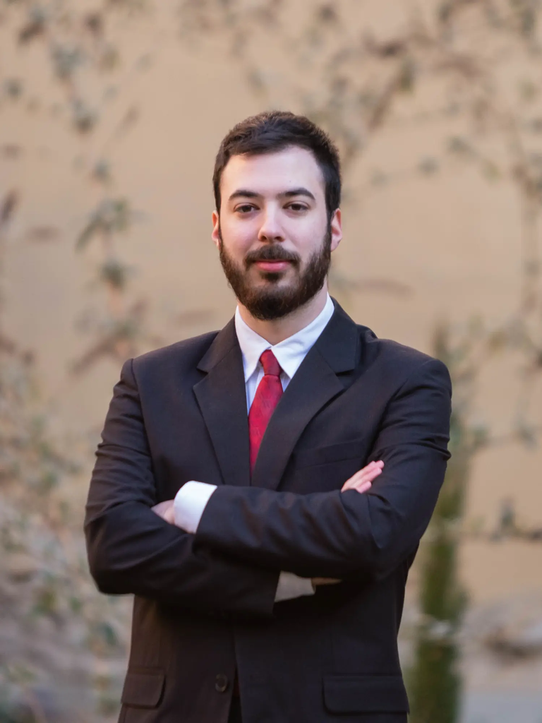

A Pécsi Tudományegyetem Természettudományi Karának negyedéves földrajz-történelem tanár szakos hallgatója vagyok. A külügyi munkacsoport elsődleges feladata a kollégium és a külsős személyek, illetve intézmények közötti kapcsolattartás. Kis csapatunk foglalkozik továbbá a kollégium alumni-csoportjának kezelésével és a remek közös programok szervezésével a tagok számára. A tavaszi félév során mi bonyolítjuk le a kollégiumi véradást is, illetve az őszi időszakban jótékonykodással igyekszünk erősíteni a ferences lelkiség gyakorlását a városban. A külügyi munkacsoport tartja a kapcsolatot a más pécsi keresztény közösségekkel is, így csatolva be a kollégiumot a szélesebb, Krisztusi gyülekezetbe.

### Lelki Munkacsoport: Ocskay Flóra Anna

**Bemutatkozás**

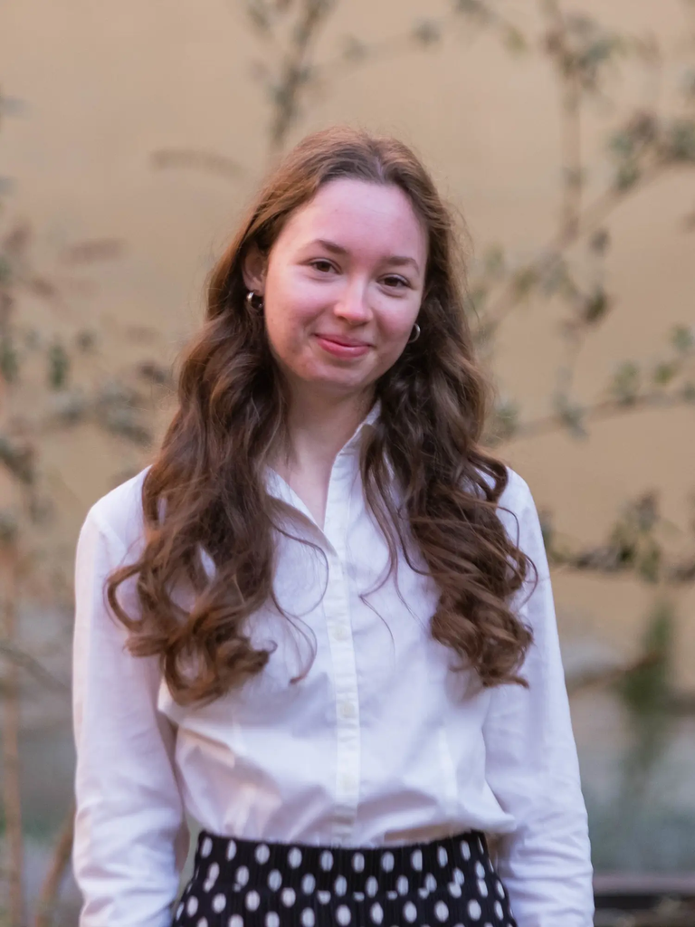

A Pécsi Tudományegyetem Bölcsészet- és Társadalomtudományi Karának történelem szakos hallgatója vagyok. A lelki munkacsoport vezetőjeként a kollégisták Istennel való kapcsolatteremtését, valamint kapcsolattartását próbálom segíteni a munkacsoportommal. Ehhez szentségimádásokat, esti imákat és számos lelki programot szervezünk. Munkánkat segíti egy lelkes zenész csapat is.

### Toborzó Munkacsoport: Böhm Kristóf

**Bemutatkozás**

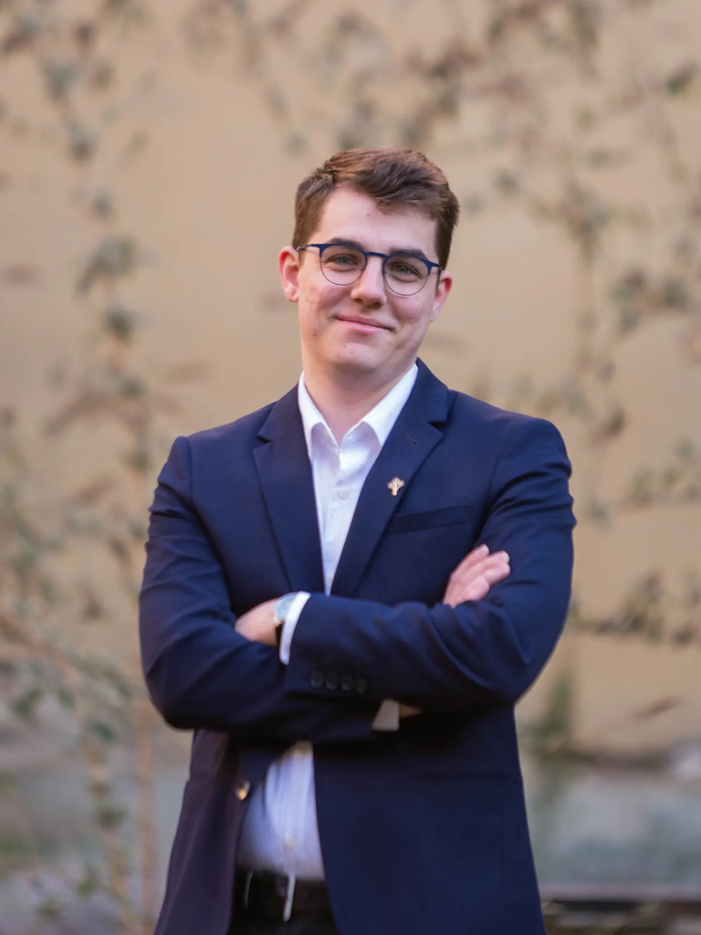

A Pécsi Tudományegyetem Egészségtudományi Karának Mentőtiszt szakos hallgatója vagyok. A Toborzó Munkacsoport vezetőjeként egy barátságos, s egyben professzionális környezetben dolgozunk azért, hogy a jövő kollégistái számára egy vonzó lakhatási lehetőség legyen a Szeráf. Továbbá az újonnan érkezett kollégisták beilleszkedését is segítjük csapatommal, ezért szeretnénk a következő félévben is megszervezni a „Mentor programot”. Ezek mellett a kollégiumi felvételiért és „merchandise” termékekért is mi felelünk.